# chapter3

Mohammad Imangholiloo

12 November 2020

# *Exercise 3:* **Logistic regression analysis**

In this script we assess Student Performance Data Set from *URL: https://archive.ics.uci.edu/ml/datasets/Student+Performance*

**Data description:**  
This data approach student achievement in secondary education of two Portuguese schools. The data attributes include student grades, demographic, social and school related features) and it was collected by using school reports and questionnaires. Two datasets are provided regarding the performance in two distinct subjects: Mathematics (mat) and Portuguese language (por). *For more info visit: https://archive.ics.uci.edu/ml/datasets/Student+Performance*

## *Part 1) Data wrangling*

```r
# Read the data to R
# Set working directory
setwd("C:/Users/Mohammad/Documents/IODS-project/data")

# read math class questionnaire data into memory
student_mat=read.csv("student-mat.csv",sep=";",header=TRUE)

# Read portuguese class questionnaire data into memory
student_por=read.csv("student-por.csv",sep=";",header=TRUE)

# check dimensions of both data
dim(student_mat)
```

```
## [1] 395  33
```

```r
dim(student_por)
```

```
## [1] 649  33
```

```r
# check structure of both data
"str(student_mat)" # I comment these lines out to shorten the report
```

```
## [1] "str(student_mat)"
```

```r
"str(student_por)"
```

```
## [1] "str(student_por)"
```

```r
# check first 5 rows of both data
'head(student_mat)' # I comment these lines out to shorten the report
```

```
## [1] "head(student_mat)"
```

```r
'head(student_por)'
```

```
## [1] "head(student_por)"
```

```r
# check last 5 rows of both data
'tail(student_mat)' # I comment these lines out to shorten the report
```

```
## [1] "tail(student_mat)"
```

```r
'tail(student_por)'
```

```
## [1] "tail(student_por)"
```

```r
#a short view about descriptive statistical features of the columns, e.g. mean, min, max, etc.
summary(student_mat)
```

```
##     school              sex                 age         address
##  Length:395         Length:395         Min.   :15.0   Length:395
##  Class :character   Class :character   1st Qu.:16.0   Class :character
##  Mode  :character   Mode  :character   Median :17.0   Mode  :character
##                                        Mean   :16.7
##                                        3rd Qu.:18.0
##                                        Max.   :22.0
##    famsize            Pstatus               Medu            Fedu
##  Length:395         Length:395         Min.   :0.000   Min.   :0.000
##  Class :character   Class :character   1st Qu.:2.000   1st Qu.:2.000
##  Mode  :character   Mode  :character   Median :3.000   Median :2.000
##                                        Mean   :2.749   Mean   :2.522
##                                        3rd Qu.:4.000   3rd Qu.:3.000
##                                        Max.   :4.000   Max.   :4.000
##      Mjob               Fjob              reason            guardian
##  Length:395         Length:395         Length:395         Length:395
##  Class :character   Class :character   Class :character   Class :character
##  Mode  :character   Mode  :character   Mode  :character   Mode  :character
##
##
##
##    traveltime      studytime        failures       schoolsup
##  Min.   :1.000   Min.   :1.000   Min.   :0.0000   Length:395
##  1st Qu.:1.000   1st Qu.:1.000   1st Qu.:0.0000   Class :character
##  Median :1.000   Median :2.000   Median :0.0000   Mode  :character
##  Mean   :1.448   Mean   :2.035   Mean   :0.3342
##  3rd Qu.:2.000   3rd Qu.:2.000   3rd Qu.:0.0000
##  Max.   :4.000   Max.   :4.000   Max.   :3.0000
##     famsup              paid            activities          nursery
##  Length:395         Length:395         Length:395         Length:395
##  Class :character   Class :character   Class :character   Class :character
##  Mode  :character   Mode  :character   Mode  :character   Mode  :character
##
##
##
##     higher            internet           romantic             famrel
##  Length:395         Length:395         Length:395         Min.   :1.000
##  Class :character   Class :character   Class :character   1st Qu.:4.000
##  Mode  :character   Mode  :character   Mode  :character   Median :4.000
##                                                           Mean   :3.944
```

[output cut: 8 more lines]

```
##  Max.   :5.000   Max.   :5.000   Max.   :5.000   Max.   :5.000
##      health         absences            G1              G2
##  Min.   :1.000   Min.   : 0.000   Min.   : 3.00   Min.   : 0.00
##  1st Qu.:3.000   1st Qu.: 0.000   1st Qu.: 8.00   1st Qu.: 9.00
##  Median :4.000   Median : 4.000   Median :11.00   Median :11.00
##  Mean   :3.554   Mean   : 5.709   Mean   :10.91   Mean   :10.71
##  3rd Qu.:5.000   3rd Qu.: 8.000   3rd Qu.:13.00   3rd Qu.:13.00
##  Max.   :5.000   Max.   :75.000   Max.   :19.00   Max.   :19.00
##        G3
##  Min.   : 0.00
##  1st Qu.: 8.00
##  Median :11.00
##  Mean   :10.42
##  3rd Qu.:14.00
##  Max.   :20.00
```

```r
summary(student_por)
```

```
##     school              sex                 age          address
##  Length:649         Length:649         Min.   :15.00   Length:649
##  Class :character   Class :character   1st Qu.:16.00   Class :character
##  Mode  :character   Mode  :character   Median :17.00   Mode  :character
##                                        Mean   :16.74
##                                        3rd Qu.:18.00
##                                        Max.   :22.00
##    famsize            Pstatus               Medu            Fedu
##  Length:649         Length:649         Min.   :0.000   Min.   :0.000
##  Class :character   Class :character   1st Qu.:2.000   1st Qu.:1.000
##  Mode  :character   Mode  :character   Median :2.000   Median :2.000
##                                        Mean   :2.515   Mean   :2.307
##                                        3rd Qu.:4.000   3rd Qu.:3.000
##                                        Max.   :4.000   Max.   :4.000
##      Mjob               Fjob              reason            guardian
##  Length:649         Length:649         Length:649         Length:649
##  Class :character   Class :character   Class :character   Class :character
##  Mode  :character   Mode  :character   Mode  :character   Mode  :character
##
##
##
##    traveltime      studytime        failures       schoolsup
##  Min.   :1.000   Min.   :1.000   Min.   :0.0000   Length:649
##  1st Qu.:1.000   1st Qu.:1.000   1st Qu.:0.0000   Class :character
##  Median :1.000   Median :2.000   Median :0.0000   Mode  :character
##  Mean   :1.569   Mean   :1.931   Mean   :0.2219
##  3rd Qu.:2.000   3rd Qu.:2.000   3rd Qu.:0.0000
##  Max.   :4.000   Max.   :4.000   Max.   :3.0000
##     famsup              paid            activities          nursery
##  Length:649         Length:649         Length:649         Length:649
##  Class :character   Class :character   Class :character   Class :character
##  Mode  :character   Mode  :character   Mode  :character   Mode  :character
##
##
##
##     higher            internet           romantic             famrel
##  Length:649         Length:649         Length:649         Min.   :1.000
##  Class :character   Class :character   Class :character   1st Qu.:4.000
##  Mode  :character   Mode  :character   Mode  :character   Median :4.000
##                                                           Mean   :3.931
##                                                           3rd Qu.:5.000
##                                                           Max.   :5.000
##     freetime        goout            Dalc            Walc          health
##  Min.   :1.00   Min.   :1.000   Min.   :1.000   Min.   :1.00   Min.   :1.000
##  1st Qu.:3.00   1st Qu.:2.000   1st Qu.:1.000   1st Qu.:1.00   1st Qu.:2.000
##  Median :3.00   Median :3.000   Median :1.000   Median :2.00   Median :4.000
##  Mean   :3.18   Mean   :3.185   Mean   :1.502   Mean   :2.28   Mean   :3.536
##  3rd Qu.:4.00   3rd Qu.:4.000   3rd Qu.:2.000   3rd Qu.:3.00   3rd Qu.:5.000
##  Max.   :5.00   Max.   :5.000   Max.   :5.000   Max.   :5.00   Max.   :5.000
##     absences            G1             G2              G3
##  Min.   : 0.000   Min.   : 0.0   Min.   : 0.00   Min.   : 0.00
##  1st Qu.: 0.000   1st Qu.:10.0   1st Qu.:10.00   1st Qu.:10.00
##  Median : 2.000   Median :11.0   Median :11.00   Median :12.00
##  Mean   : 3.659   Mean   :11.4   Mean   :11.57   Mean   :11.91
##  3rd Qu.: 6.000   3rd Qu.:13.0   3rd Qu.:13.00   3rd Qu.:14.00
##  Max.   :32.000   Max.   :19.0   Max.   :19.00   Max.   :19.00
```

```r
#column names are printed in console
colnames(student_mat)
```

```
##  [1] "school"     "sex"        "age"        "address"    "famsize"
##  [6] "Pstatus"    "Medu"       "Fedu"       "Mjob"       "Fjob"
## [11] "reason"     "guardian"   "traveltime" "studytime"  "failures"
## [16] "schoolsup"  "famsup"     "paid"       "activities" "nursery"
## [21] "higher"     "internet"   "romantic"   "famrel"     "freetime"
## [26] "goout"      "Dalc"       "Walc"       "health"     "absences"
## [31] "G1"         "G2"         "G3"
```

```r
colnames(student_por)
```

```
##  [1] "school"     "sex"        "age"        "address"    "famsize"
##  [6] "Pstatus"    "Medu"       "Fedu"       "Mjob"       "Fjob"
## [11] "reason"     "guardian"   "traveltime" "studytime"  "failures"
## [16] "schoolsup"  "famsup"     "paid"       "activities" "nursery"
## [21] "higher"     "internet"   "romantic"   "famrel"     "freetime"
## [26] "goout"      "Dalc"       "Walc"       "health"     "absences"
## [31] "G1"         "G2"         "G3"
```

```r
#to show the number of observations based on their school name
table(student_mat$school)
```

```
##
##  GP  MS
## 349  46
```

```r
table(student_por$school)
```

```
##
##  GP  MS
## 423 226
```

Merge two datasets usig dplyr library

```r
# load library
library(dplyr)
# make a list of common columns to be used as identifiers in both datasets when merging
join_by_columns <- c("school","sex","age","address","famsize","Pstatus","Medu",
                     "Fedu","Mjob","Fjob","reason","nursery","internet")

# join the two datasets by inner join function of the dplyr library, using the selected identifiers
# Note: inner_join keeps only rows (observations) that arein both input datasets
students_math_por_joint <- inner_join(student_mat, student_por,
                                      by = join_by_columns, suffix = c("_math", "_por"))

#check dimention of newly merged dataset
dim(students_math_por_joint) # 382 students
```

```
## [1] 382  53
```

```r
# see the new column names
colnames(students_math_por_joint)
```

```
##  [1] "school"          "sex"             "age"             "address"
##  [5] "famsize"         "Pstatus"         "Medu"            "Fedu"
##  [9] "Mjob"            "Fjob"            "reason"          "guardian_math"
## [13] "traveltime_math" "studytime_math"  "failures_math"   "schoolsup_math"
## [17] "famsup_math"     "paid_math"       "activities_math" "nursery"
## [21] "higher_math"     "internet"        "romantic_math"   "famrel_math"
## [25] "freetime_math"   "goout_math"      "Dalc_math"       "Walc_math"
## [29] "health_math"     "absences_math"   "G1_math"         "G2_math"
## [33] "G3_math"         "guardian_por"    "traveltime_por"  "studytime_por"
## [37] "failures_por"    "schoolsup_por"   "famsup_por"      "paid_por"
## [41] "activities_por"  "higher_por"      "romantic_por"    "famrel_por"
## [45] "freetime_por"    "goout_por"       "Dalc_por"        "Walc_por"
## [49] "health_por"      "absences_por"    "G1_por"          "G2_por"
## [53] "G3_por"
```

```r
# view the file in R
#View(students_math_por_joint)

# glimpse at the data, it is like str() but prints more data. In other words, like a transposed version of print()
'glimpse(students_math_por_joint)' # I comment theis line out to shorten the
```

```
## [1] "glimpse(students_math_por_joint)"
```

```r
# check data structure
'str(students_math_por_joint)' # I comment these lines out to shorten the report
```

```
## [1] "str(students_math_por_joint)"
```

Combine the ‘duplicated’ answers in the joined data

```r
# create a new data frame with only the joined columns
alc <- select(students_math_por_joint, one_of(join_by_columns))

# columns that were not used for joining the data
notjoined_columns <- colnames(student_mat)[!colnames(student_mat) %in% join_by_columns]

# print out the columns not used for joining
notjoined_columns
```

```
##  [1] "guardian"   "traveltime" "studytime"  "failures"   "schoolsup"
##  [6] "famsup"     "paid"       "activities" "higher"     "romantic"
## [11] "famrel"     "freetime"   "goout"      "Dalc"       "Walc"
## [16] "health"     "absences"   "G1"         "G2"         "G3"
```

```r
# for every column name not used for joining...
for(column_name in notjoined_columns) {
  # print the column bane while looping to show the progress
  print(column_name)
  # select two columns from 'math_por' with the same original name
  two_columns <- select(students_math_por_joint, starts_with(column_name))
  # select the first column vector of those two columns
  first_column <- select(two_columns, 1)[[1]]

  # if that first column  vector is numeric...
  if(is.numeric(first_column)) {
    # take a rounded average of each row of the two columns and
    # add the resulting vector to the alc data frame
    alc[column_name] <- round(rowMeans(two_columns))
  } else { # else if it's not numeric...
    # add the first column vector to the alc data frame
    alc[column_name] <- first_column
  }
}
```

```
## [1] "guardian"
## [1] "traveltime"
## [1] "studytime"
## [1] "failures"
## [1] "schoolsup"
## [1] "famsup"
## [1] "paid"
## [1] "activities"
## [1] "higher"
## [1] "romantic"
## [1] "famrel"
## [1] "freetime"
## [1] "goout"
## [1] "Dalc"
## [1] "Walc"
## [1] "health"
## [1] "absences"
## [1] "G1"
## [1] "G2"
## [1] "G3"
```

```r
# glimpse at the new combined data
'glimpse(alc)' # I comment these lines out to shorten the report
```

```
## [1] "glimpse(alc)"
```

Define a new column alc_use by combining weekday and weekend alcohol use (i.e. columns Dalc and Walc, respectively)

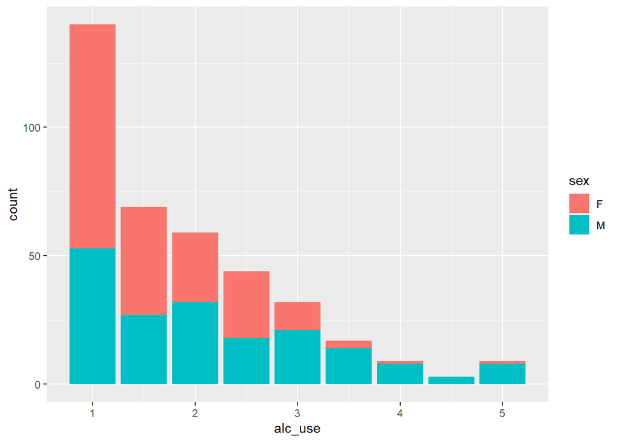

```r
alc <- mutate(alc, alc_use = (Dalc + Walc) / 2)

# load library for plotting
library(ggplot2)

# Let's plot the alcohol use based on gender
g1 <- ggplot(data = alc, aes(x = alc_use, fill = sex))

# define the plot as a bar plot and draw it
g1 + geom_bar()
```

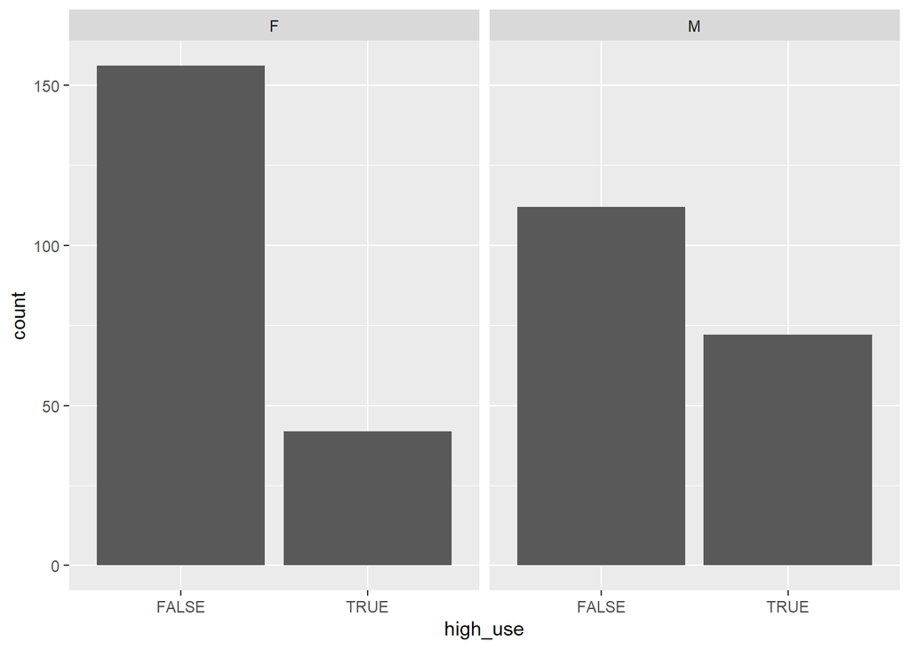

```r
# create a new logical column named 'high_use'. This column will make a True/Fale column if consuption is >2
alc <- mutate(alc, high_use = alc_use > 2)

# initialize a plot of 'high_use'
g2 <- ggplot(alc, aes(high_use))

# draw a bar plot of high_use by sex
g2 + facet_wrap("sex") + geom_bar()
```

### **Extra coding 1: Lets check it by table also**

```r
table(alc$high_use)
```

```
##
## FALSE  TRUE
##   268   114
```

```r
"as it shows 114 students were consumed alcohol more than threshold (2) so were high use"
```

```
## [1] "as it shows 114 students were consumed alcohol more than threshold (2) so were high use"
```

```r
table(alc$high_use)/nrow(alc)*100
```

```
##
##    FALSE     TRUE
## 70.15707 29.84293
```

```r
"It means that 29.84% of students were high use, while majority (70.15%) were low use"
```

```
## [1] "It means that 29.84% of students were high use, while majority (70.15%) were low use"
```

```r
table(alc$alc_use)/nrow(alc)*100
```

```
##
##          1        1.5          2        2.5          3        3.5          4
## 36.6492147 18.0628272 15.4450262 11.5183246  8.3769634  4.4502618  2.3560209
##        4.5          5
##  0.7853403  2.3560209
```

```r
"as this shows, majoriy of them (36.65%) consumed just 1"
```

```
## [1] "as this shows, majoriy of them (36.65%) consumed just 1"
```

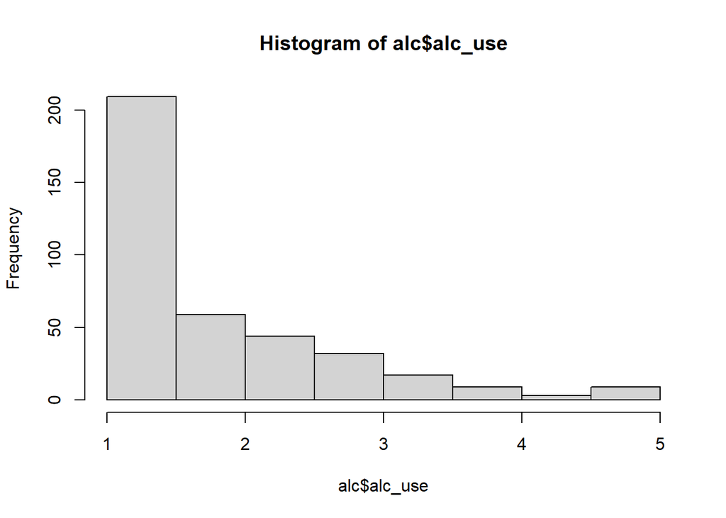

```r
# Let's make a histogram and check the distribution
hist(alc$alc_use)
```

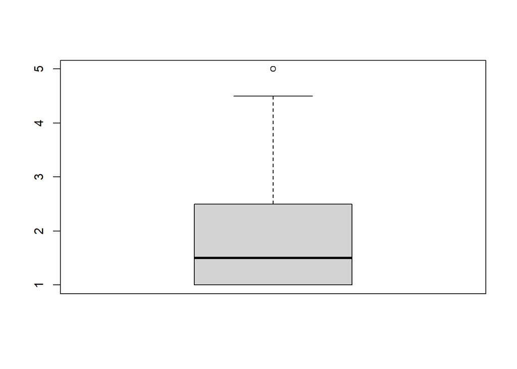

```r
# Let's make a boxplot to further see the distribution
boxplot(alc$alc_use)
```

```r
# read libraries
library(tidyr); library(dplyr); library(ggplot2)

# glimpse at the alc data
glimpse(alc)
```

```
## Rows: 382
## Columns: 35
## $ school     <chr> "GP", "GP", "GP", "GP", "GP", "GP", "GP", "GP", "GP", "G...
## $ sex        <chr> "F", "F", "F", "F", "F", "M", "M", "F", "M", "M", "F", "...
## $ age        <int> 18, 17, 15, 15, 16, 16, 16, 17, 15, 15, 15, 15, 15, 15, ...
## $ address    <chr> "U", "U", "U", "U", "U", "U", "U", "U", "U", "U", "U", "...
## $ famsize    <chr> "GT3", "GT3", "LE3", "GT3", "GT3", "LE3", "LE3", "GT3", ...
## $ Pstatus    <chr> "A", "T", "T", "T", "T", "T", "T", "A", "A", "T", "T", "...
## $ Medu       <int> 4, 1, 1, 4, 3, 4, 2, 4, 3, 3, 4, 2, 4, 4, 2, 4, 4, 3, 3,...
## $ Fedu       <int> 4, 1, 1, 2, 3, 3, 2, 4, 2, 4, 4, 1, 4, 3, 2, 4, 4, 3, 2,...
## $ Mjob       <chr> "at_home", "at_home", "at_home", "health", "other", "ser...
## $ Fjob       <chr> "teacher", "other", "other", "services", "other", "other...
## $ reason     <chr> "course", "course", "other", "home", "home", "reputation...
## $ nursery    <chr> "yes", "no", "yes", "yes", "yes", "yes", "yes", "yes", "...
## $ internet   <chr> "no", "yes", "yes", "yes", "no", "yes", "yes", "no", "ye...
```

[output cut: 22 more lines]

```r
# use gather() to gather columns into key-value pairs and then glimpse() at the resulting data
gather(alc) %>% glimpse
```

```
## Rows: 13,370
## Columns: 2
## $ key   <chr> "school", "school", "school", "school", "school", "school", "...
## $ value <chr> "GP", "GP", "GP", "GP", "GP", "GP", "GP", "GP", "GP", "GP", "...
```